# Amostragem Aula 2

2024-03-24

### Exemplo 1A :

Seja $U = {1, 2, 3}$. Sorteia-se com igual probabilidade um elemento de $U$ e anota-se a unidade sorteada. Este elemento é devolvido à população e sorteia-se um segundo elemento do mesmo modo.

$S_A(U) = ?$ $P_A = ?$

Como estamos interessados no numero de amostras possiveis a ordem importa nesse caso. O R tem funcoes que geram as combinacoes possiveis com ou sem repeticao porem nao levam em consideracao a ordem, aqui está um exemplo:

```r
comb = comboGeneral(1:3,2,repetition = T)
```

```
##      [,1] [,2]
## [1,]    1    1
## [2,]    1    2
## [3,]    1    3
## [4,]    2    2
## [5,]    2    3
## [6,]    3    3
```

Contudo o resultado correto seria:

$$S_A(U) = {11, 12, 13, 21, 22, 23, 31, 32, 33}$$
$P_A = \frac{1}{9}$ e 0 caso contrario

### Exemplo 1B :

Seja $U = {1, 2, 3}$. Sorteia-se com igual probabilidade um elemento de $U$ e anota-se a unidade sorteada. Este elemento é retirado à população e sorteia-se um segundo elemento do mesmo modo.

$S_B(U) = ?$ $P_B = ?$

Aqui novamente a ordem ainda importa contudo nao podemos ter amostras repetidas:

$S_B(U) = {12, 13, 21, 23, 31, 32}$

$P_B = \frac{1}{6}$

### Exemplo 1C :

Sorteia-se uma unidade após a outra, repondo-se a unidade sorteada antes de sortear a seguinte, até o surgimento da unidade 2 (i = 2), ou até que 3 unidades tenham sido sorteadas.

$S_C(U) = ?$ $P_C = ?$

$S_C(U) = {2, 12, 32, 112, 132, 312, 332, 111, 113, 131, 311, 133, 313, 331, 333}$

Vamos calcular a probabilidade de sair somente um ate os 3:

$P(2) = \frac{1}{3}$

$P(12) = P_(32) = \frac{1}{3} \cdot \frac{1}{3} = \frac{1}{9}$

$P(112)= ... = P_(333) = \frac{1}{3} \cdot \frac{1}{3} \cdot \frac{1}{3} = \frac{1}{27}$

### Exemplo 2A - Distribuicao Amostral :

Considere que o interesse esteja nas variáveis Renda e Número de Trabalhadores, i.e., no vetor $(F_i, T_i)$,considerando a seguinte matriz de dados:

$$d_s = \begin{bmatrix}
12 & 30 & 18 \\
1 & 3 & 2 \\
\end{bmatrix}$$

Considere o $P_A(A)$ e a distribuição amostral da razão entre o total da renda familiar e o número de trabalhadores, i.e., da estatística $R = h(Ds)$.

Vamos fazer um codigo para calcular a razao entre essas amostras:

```r
renda <- c(12, 30, 18)
ntrab <- c(1, 3, 2)
results <- c()
amostra <- c(1, 1, 1, 2, 1, 3, 2, 1, 2, 2, 2, 3, 3, 1, 3, 2, 3, 3)
t= 0
for (i in seq(1, length(amostra)/2)) {
  r <- (renda[amostra[i+t]] + renda[amostra[i+t+1]]) / (ntrab[amostra[i+t]] + ntrab[amostra[i+t+1]])
  results <- append(results, r)
  t=t+1
}

print(results)
```

```
## [1] 12.0 10.5 10.0 10.5 10.0  9.6 10.0  9.6  9.0
```

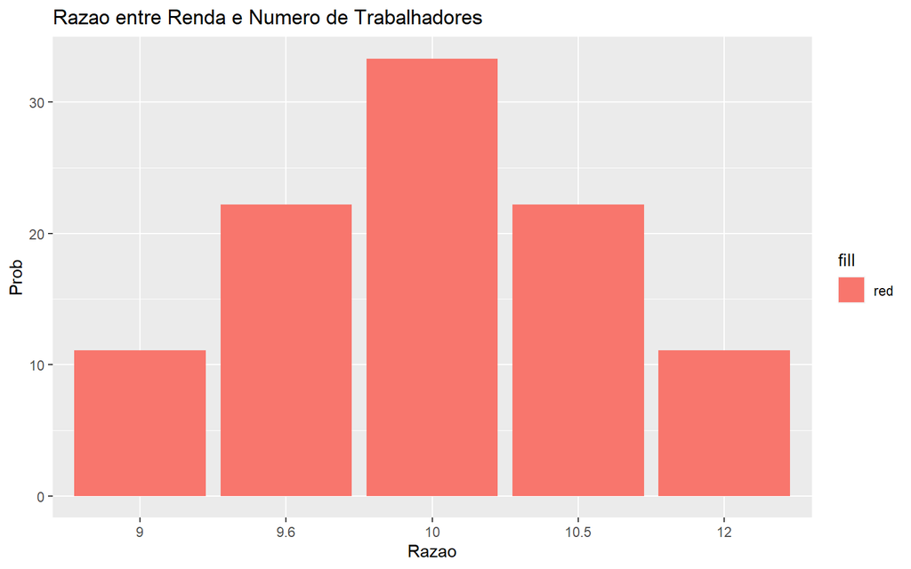

### Exemplo 2B - Distribuicao Amostral :

Considere que o interesse esteja nas variáveis Renda e Número de Trabalhadores, i.e., no vetor $(F_i, T_i)$,considerando a seguinte matriz de dados:

$$d_s = \begin{bmatrix}
12 & 30 & 18 \\
1 & 3 & 2 \\
\end{bmatrix}$$

Considere o $P_B(B)$ e a distribuição amostral da razão entre o total da renda familiar e o número de trabalhadores, i.e., da estatística $R = h(Ds)$.

Vamos fazer um codigo para calcular a razao entre essas amostras:

```r
renda <- c(12, 30, 18)
ntrab <- c(1, 3, 2)
resultsB <- c()
amostra <- c( 1, 2, 1, 3, 2, 1, 2, 3, 3, 1, 3, 2)
t= 0
for (i in seq(1, length(amostra)/2)) {
  r <- (renda[amostra[i+t]] + renda[amostra[i+t+1]]) / (ntrab[amostra[i+t]] + ntrab[amostra[i+t+1]])
  resultsB <- append(resultsB, r)
  t=t+1
}

print(resultsB)
```

```
## [1] 10.5 10.0 10.5  9.6 10.0  9.6
```

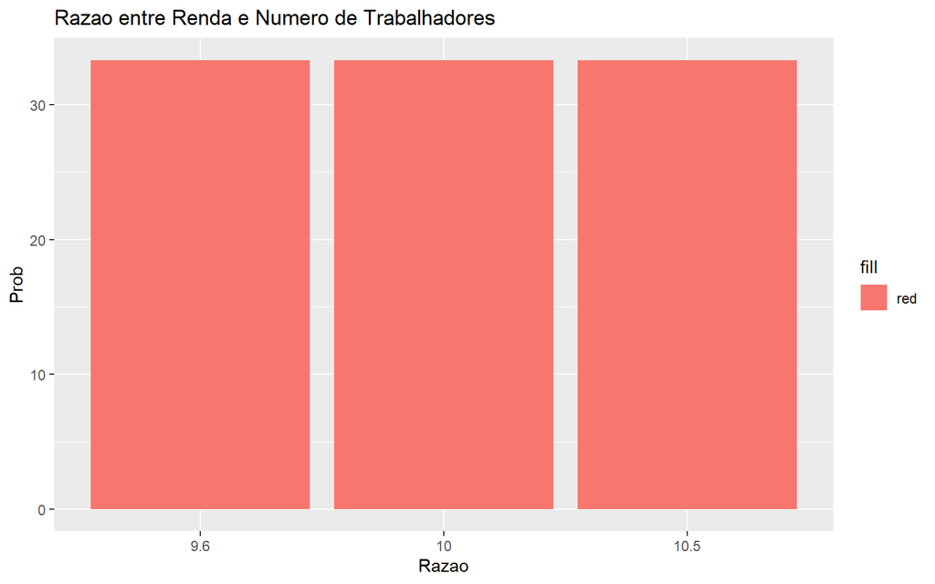

### Exemplo 3A - Esperanca e Variancia :

Para o exemplo com o $P_A(A)$, obtém-se a distribuição amostral para razão a partir do vetor de dados: $d_s = (12,30,18)$

Nosso vetor da Razao é

```r
print(results)
```

```
## [1] 12.0 10.5 10.0 10.5 10.0  9.6 10.0  9.6  9.0
```

Para Calcular a esperanca é necessario multiplicar a probabilidade de ocorrencia de um valor por ele mesmo, logo no exemplo a todos tem a probabilidade de $\frac{1}{9}$

$$E(X) = \sum_i x_i \cdot p(x_i)$$

$$Var(X) = E(X^2) - (E(X))^2$$

```r
esp = sum(results * 1/9)
esp_quad = sum((results^2) * 1/9)

var = esp_quad - esp^2
```

```
## [1] 10.13333
```

```
## [1] 0.6288889
```

### Exemplo 3B - Covariancia e Correlacao :

Para o exemplo com o $P_A(A)$, obtém-se a distribuição amostral para renda média $(\overline f)$ a partir do vetor de dados: $d_s = (12,30,18)$

```r
renda <- c(12, 30, 18)
resultsF <- c()
amostra <- c(1, 1, 1, 2, 1, 3, 2, 1, 2, 2, 2, 3, 3, 1, 3, 2, 3, 3)
t= 0
for (i in seq(1, length(amostra)/2)) {
  r <- ((renda[amostra[i+t]] + renda[amostra[i+t+1]]) / 2)
  resultsF <- append(resultsF, r)
  t=t+1
}

print(resultsF)
```

```
## [1] 12 21 15 21 30 24 15 24 18
```

Nesse caso a probabilidade de cada media continua sendo $\frac{1}{9}$

```r
espF = sum(resultsF * 1/9)
esp_quadF = sum((resultsF^2) * 1/9)

varF = esp_quadF - espF^2
```

```
## [1] 20
```

```
## [1] 28
```

Para calular a Correlacao e Covariacia vamos usar a as seguintes formulas:

$$Cov(X,Y) = \frac{\sum_i [x_i - E(x)][y_i - E(Y)]}{N} \ \ \ \text{Para a
populacao}$$

$$Cov(X,Y) = \frac{\sum_i [x_i - E(x)][y_i - E(Y)]}{n-1} \ \ \ \text{Para
a amostra}$$

$$Cov(X,Y) = E(XY) - E(X)E(Y)$$

$$Cor(X,Y) = \frac{\sum_i [x_i - E(x)][y_i - E(Y)]}{\sqrt{\sum_i [x_i -
E(x)]^2[y_i - E(Y)]^2}} = \frac{E(XY) - E(X)E(Y)}{ \sqrt{E(X^2) -
(E(X))^2} \sqrt{E(Y^2) - (E(Y))^2} } = \frac{Cov(X,Y)}{\sqrt{Var(X)}
\sqrt{Var(Y)}}$$

```r
covvF = sum((results - esp)*(resultsF-espF))/9 #populacionnal

corrF = covvF/(sqrt(var*varF))
```

```
## [1] -1.8
```

```
## [1] -0.4289499
```

Podemos comparar a correlacao com a funcao ja implementada no R

```r
cor(results,resultsF)
```

```
## [1] -0.4289499
```

Podemos fazer o mesmo com a covariancia mas o R usa por padrao a amostral

```r
cov(results,resultsF)
```

```
## [1] -2.025
```

### Exemplo 3B - Viés e Erro Quadratico Médio :

Um estimador $ (d_s)$ é dito não viciado segundo um plano amostral A, se:

$$E(\hat\theta) = \theta$$

O viés (ou vício) do estimador $ (d_s)$, segundo o plano amostral A, é dado por:

$$B_A(\hat\theta) = E(\hat\theta - \theta) = E(\hat\theta) - \theta$$
e o Erro Quadrático Médio por:

$$EQM_A(\hat\theta) = E(\hat\theta - \theta)^2 = Var(\hat\theta) +
B^2(\hat\theta)$$

Com base na distribuição amostral de $\overline f$ verificou-se que trata-se de um estimado não viesado para a renda média familiar, $\mu F = 20$, visto que:

A media tem valor igual a:

```r
mean(renda)
```

```
## [1] 20
```

e a esperanca que encontramos para $\overline f$ é:

```r
print(espF)
```

```
## [1] 20
```

Como a média e a esperanca sao iguais logoa media nao é um estimador enviesado e sabemos que nosso vies é 0 e por consequencia o erro quadratico medio vair ser igual a variancia da renda media familiar que é igual a :

```r
print(varF)
```

```
## [1] 28
```

### Exemplo 3C - Viés e Erro Quadratico Médio :

```r
muR = sum(renda)/sum(ntrab)
```

```r
print(muR)
```

```
## [1] 10
```

Enquanto que a esperanca de R é:

```
## [1] 10.13333
```

Logo nosso vies será:

```r
B = esp-muR
```

```
## [1] 0.1333333
```

Já nosso EQM é:

```r
EQM = var + B^2
```

```
## [1] 0.6466667
```